### Author: Abul Fattah M Al Mohaimin

### Title: Practical Machine Learning - Final Project

### Date: August 10, 2016

## Overview

Using devices such as Jawbone Up, Nike FuelBand, and Fitbit it is now possible to collect a large amount of data about personal activity relatively inexpensively. These type of devices are part of the quantified self movement - a group of enthusiasts who take measurements about themselves regularly to improve their health, to find patterns in their behavior, or because they are tech geeks. One thing that people regularly do is quantify how much of a particular activity they do, but they rarely quantify how well they do it. In this project, your goal will be to use data from accelerometers on the belt, forearm, arm, and dumbell of 6 participants. They were asked to perform barbell lifts correctly and incorrectly in 5 different ways. More information is available from the website here: http://groupware.les.inf.puc-rio.br/har (see the section on the Weight Lifting Exercise Dataset).

## Preparation step: Data andlibraries loading

- Working Directory and load data

```r
setwd("C:/Users/user/Desktop/RWD/PML")
set.seed(5000)

library(knitr)
library(caret)
```

```r
library(rpart)
library(rpart.plot)
library(rattle)
library(randomForest)
library(corrplot)
trainUrl <- "http://d396qusza40orc.cloudfront.net/predmachlearn/pml-training.csv"
testUrl <- "http://d396qusza40orc.cloudfront.net/predmachlearn/pml-testing.csv"

training <- read.csv(url(trainUrl))
testing <- read.csv(url(testUrl))
```

## Partitioning data for sample error and cross validation

- Partitioning the training set for cross validation and out of sample error calculation
- Testing is used for cross validation
- Divide the Training set into 2 equal sets.

```r
library(caret)
set.seed(5000)
ids_small <- createDataPartition(training$classe, p=0.5, list=FALSE)
df_small1 <- training[ids_small,]
df_small2 <- training[-ids_small,]
# Divide each of these 2 sets into training (60%) and test (40%) sets.
# Set1
set.seed(1000)
inTrain <- createDataPartition(df_small1$classe, p=0.6, list=FALSE)
Training <- df_small1[inTrain,]
Testing <- df_small1[-inTrain,]
set.seed(1000)
#Set2
inTrain1 <- createDataPartition(df_small2$classe, p=0.6, list=FALSE)
Training1 <- df_small2[inTrain1,]
Testing1 <- df_small2[-inTrain1,]

dim(Training);dim(Training1)
```

```
## [1] 5889  160
```

```
## [1] 5887  160
```

## Cleaning the data

- Remove NearZeroVariance variables

```r
# For set1
NZV <- nearZeroVar(Training)
Training <- Training[, -NZV]
Testing  <- Testing[, -NZV]
dim(Training); dim(Testing)
```

```
## [1] 5889  113
```

```
## [1] 3923  113
```

```r
# For set2
NZV1 <- nearZeroVar(Training1)
Training1 <- Training1[, -NZV1]
Testing1  <- Testing1[, -NZV1]
dim(Training1); dim(Testing1)
```

```
## [1] 5887  107
```

```
## [1] 3923  107
```

- Remove NA variables

```r
# For set1
AllNA    <- sapply(Training, function(x) mean(is.na(x))) > 0.95
Training <- Training[, AllNA==FALSE]
Testing  <- Testing[, AllNA==FALSE]
dim(Training); dim(Testing)
```

```
## [1] 5889   59
```

```
## [1] 3923   59
```

```r
# For set2
AllNA1    <- sapply(Training1, function(x) mean(is.na(x))) > 0.95
Training1 <- Training1[, AllNA1==FALSE]
Testing1  <- Testing1[, AllNA1==FALSE]
dim(Training1); dim(Testing1)
```

```
## [1] 5887   59
```

```
## [1] 3923   59
```

- Rmove identification only variables (columns 1 to 5)

```r
# For set 1
Training <- Training[, -(1:5)]
Testing  <- Testing[, -(1:5)]
dim(Training); dim(Testing)
```

```
## [1] 5889   54
```

```
## [1] 3923   54
```

```r
# For set 2
Training1 <- Training1[, -(1:5)]
Testing1  <- Testing1[, -(1:5)]
dim(Training1); dim(Testing1)
```

```
## [1] 5887   54
```

```
## [1] 3923   54
```

### Prediction Model Building

Three prediction model methods - Random Forests, Decision Tree and Generalized Boosted Model - will be applied for the Training dataset, then the best one with highest accuracy when applied to the Test dataset would be used for the quiz predictions.

## 1.Decision Trees

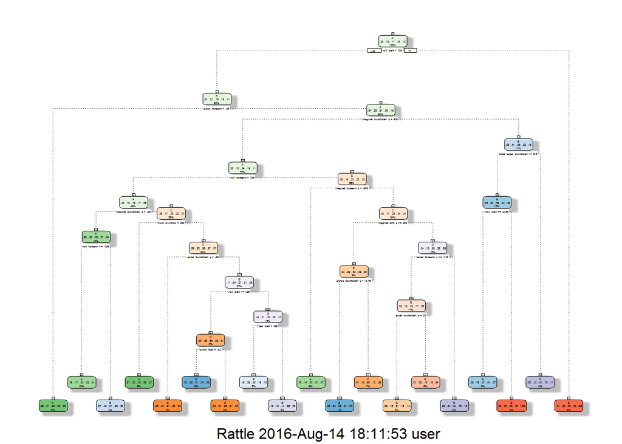

```r
set.seed(5000)
DecTree <- rpart(classe ~ ., data=Training, method="class")
fancyRpartPlot(DecTree)
```

-Applied it to Testing Set

```r
predictDecTree <- predict(DecTree, newdata=Testing, type="class")
confMatDecTree <- confusionMatrix(predictDecTree, Testing$classe)
confMatDecTree
```

```
## Confusion Matrix and Statistics
##
##           Reference
## Prediction   A   B   C   D   E
##          A 968  93  11  37  40
##          B  72 478  74  84  67
##          C  14  87 503  64  55
##          D  59  74  57 422  66
##          E   3  27  39  36 493
##
## Overall Statistics
##
##                Accuracy : 0.7301
##                  95% CI : (0.7159, 0.7439)
##     No Information Rate : 0.2845
##     P-Value [Acc > NIR] : < 2.2e-16
##
##                   Kappa : 0.6583
##  Mcnemar's Test P-Value : 3.445e-11
##
## Statistics by Class:
##
##                      Class: A Class: B Class: C Class: D Class: E
## Sensitivity            0.8674   0.6298   0.7354   0.6563   0.6838
## Specificity            0.9355   0.9061   0.9321   0.9220   0.9672
## Pos Pred Value         0.8425   0.6168   0.6957   0.6224   0.8244
## Neg Pred Value         0.9466   0.9107   0.9434   0.9319   0.9314
## Prevalence             0.2845   0.1935   0.1744   0.1639   0.1838
## Detection Rate         0.2467   0.1218   0.1282   0.1076   0.1257
## Detection Prevalence   0.2929   0.1976   0.1843   0.1728   0.1524
## Balanced Accuracy      0.9015   0.7680   0.8337   0.7891   0.8255
```

– Plot the results

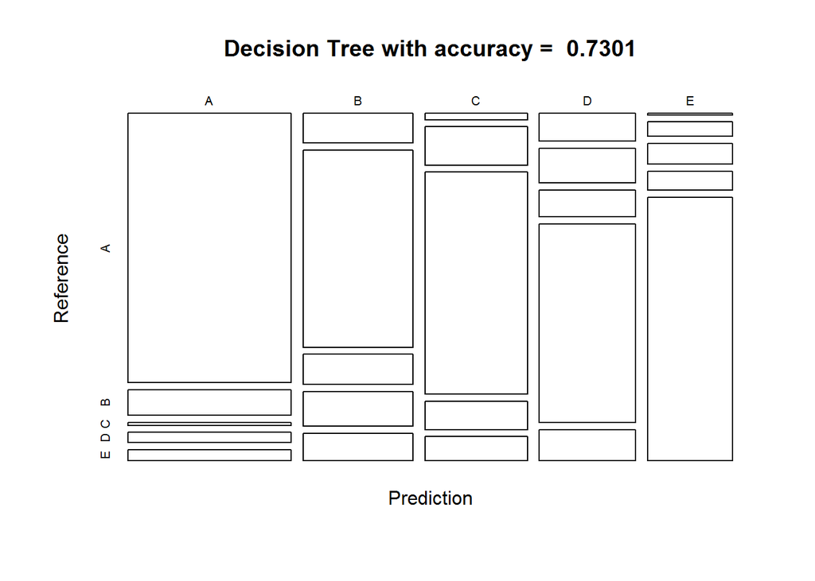

```r
plot(confMatDecTree$table, col = confMatDecTree$byClass, main = paste("Decision Tree with accuracy = ",round(confMatDecTree$overall['Accuracy'], 4)))
```

## 2.Random Forest

```r
set.seed(5000)
RF <- trainControl(method="cv", number=3, verboseIter=FALSE)
modFitRandForest <- train(classe ~ ., data=Training, method="rf",trControl=RF)
modFitRandForest$finalModel
```

```
##
## Call:
##  randomForest(x = x, y = y, mtry = param$mtry)
##                Type of random forest: classification
##                      Number of trees: 500
## No. of variables tried at each split: 27
##
##         OOB estimate of  error rate: 0.88%
## Confusion matrix:
##      A    B    C   D    E  class.error
## A 1673    1    0   0    0 0.0005973716
## B    9 1121   10   0    0 0.0166666667
## C    0    8 1017   2    0 0.0097370983
## D    0    0   11 954    0 0.0113989637
## E    0    4    1   6 1072 0.0101569714
```

– Applied it to testing set

```r
predictRandForest <- predict(modFitRandForest, newdata=Testing)
confMatRandForest <- confusionMatrix(predictRandForest, Testing$classe)
confMatRandForest
```

```
## Confusion Matrix and Statistics
##
##           Reference
## Prediction    A    B    C    D    E
##          A 1114    8    0    0    0
##          B    0  745    1    0    0
##          C    0    6  682    6    0
##          D    1    0    1  637    6
##          E    1    0    0    0  715
##
## Overall Statistics
##
##                Accuracy : 0.9924
##                  95% CI : (0.9891, 0.9948)
##     No Information Rate : 0.2845
##     P-Value [Acc > NIR] : < 2.2e-16
##
##                   Kappa : 0.9903
##  Mcnemar's Test P-Value : NA
##
## Statistics by Class:
##
##                      Class: A Class: B Class: C Class: D Class: E
## Sensitivity            0.9982   0.9816   0.9971   0.9907   0.9917
## Specificity            0.9971   0.9997   0.9963   0.9976   0.9997
## Pos Pred Value         0.9929   0.9987   0.9827   0.9876   0.9986
## Neg Pred Value         0.9993   0.9956   0.9994   0.9982   0.9981
## Prevalence             0.2845   0.1935   0.1744   0.1639   0.1838
## Detection Rate         0.2840   0.1899   0.1738   0.1624   0.1823
## Detection Prevalence   0.2860   0.1902   0.1769   0.1644   0.1825
## Balanced Accuracy      0.9977   0.9906   0.9967   0.9941   0.9957
```

– Plot the results

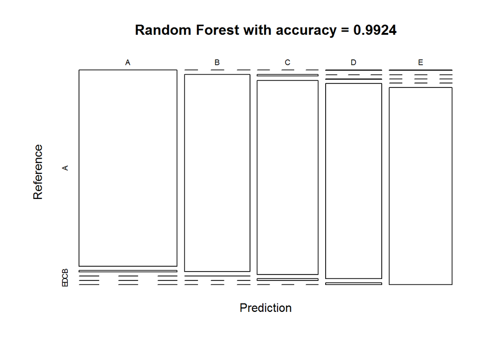

```r
plot(confMatRandForest$table, col = confMatRandForest$byClass, main = paste("Random Forest with accuracy =", round(confMatRandForest$overall['Accuracy'], 4)))
```

## 3.Generalized Boosted Model

```r
set.seed(5000)
GBM <- trainControl(method = "repeatedcv", number = 5, repeats = 1)

modFitGBM  <- train(classe ~ ., data=Training, method = "gbm", trControl = GBM, verbose = FALSE)
modFitGBM$finalModel
```

```
## A gradient boosted model with multinomial loss function.
## 150 iterations were performed.
## There were 53 predictors of which 46 had non-zero influence.
```

– Applied it to Testing Set

```r
predictGBM <- predict(modFitGBM, newdata=Testing)
confMatGBM <- confusionMatrix(predictGBM, Testing$classe)
confMatGBM
```

```
## Confusion Matrix and Statistics
##
##           Reference
## Prediction    A    B    C    D    E
##          A 1111   11    0    0    0
##          B    3  739   14    8   10
##          C    0    7  665    9    2
##          D    2    0    5  624    5
##          E    0    2    0    2  704
##
## Overall Statistics
##
##                Accuracy : 0.9796
##                  95% CI : (0.9747, 0.9838)
##     No Information Rate : 0.2845
##     P-Value [Acc > NIR] : < 2.2e-16
##
##                   Kappa : 0.9742
##  Mcnemar's Test P-Value : NA
##
## Statistics by Class:
##
##                      Class: A Class: B Class: C Class: D Class: E
## Sensitivity            0.9955   0.9736   0.9722   0.9705   0.9764
## Specificity            0.9961   0.9889   0.9944   0.9963   0.9988
## Pos Pred Value         0.9902   0.9548   0.9736   0.9811   0.9944
## Neg Pred Value         0.9982   0.9936   0.9941   0.9942   0.9947
## Prevalence             0.2845   0.1935   0.1744   0.1639   0.1838
## Detection Rate         0.2832   0.1884   0.1695   0.1591   0.1795
## Detection Prevalence   0.2860   0.1973   0.1741   0.1621   0.1805
## Balanced Accuracy      0.9958   0.9813   0.9833   0.9834   0.9876
```

– Plot the results

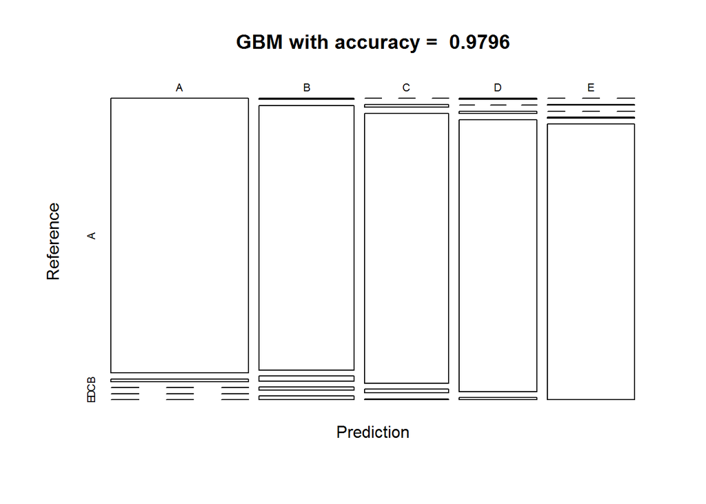

```r
plot(confMatGBM$table, col = confMatGBM$byClass, main = paste("GBM with accuracy = ", round(confMatGBM$overall['Accuracy'], 4)))
```

### Results and apply the models to the quiz

The accuracy of the 3 regression modeling methods: Decision Tree : 0.7301 Random Forest : 0.9924 GBM : 0.9796

## Out of sample error:

I applied Random Forest model on the second data set that was divided in the beginning.

```r
set.seed(5000)
RF1 <- trainControl(method="cv", number=3, verboseIter=FALSE)
modFitRandForest1 <- train(classe ~ ., data=Training1, method="rf",trControl=RF1)
modFitRandForest1$finalModel
```

```
##
## Call:
##  randomForest(x = x, y = y, mtry = param$mtry)
##                Type of random forest: classification
##                      Number of trees: 500
## No. of variables tried at each split: 27
##
##         OOB estimate of  error rate: 0.95%
## Confusion matrix:
##      A    B    C   D    E  class.error
## A 1673    1    0   0    0 0.0005973716
## B   14 1117    7   1    0 0.0193151888
## C    0    5 1017   5    0 0.0097370983
## D    0    0   13 950    2 0.0155440415
## E    0    0    0   8 1074 0.0073937153
```

– Applied it to testing set

```r
predictRandForest1 <- predict(modFitRandForest1, newdata=Testing1)
confMatRandForest1 <- confusionMatrix(predictRandForest1, Testing1$classe)
confMatRandForest
```

```
## Confusion Matrix and Statistics
##
##           Reference
## Prediction    A    B    C    D    E
##          A 1114    8    0    0    0
##          B    0  745    1    0    0
##          C    0    6  682    6    0
##          D    1    0    1  637    6
##          E    1    0    0    0  715
##
## Overall Statistics
##
##                Accuracy : 0.9924
##                  95% CI : (0.9891, 0.9948)
##     No Information Rate : 0.2845
##     P-Value [Acc > NIR] : < 2.2e-16
##
##                   Kappa : 0.9903
##  Mcnemar's Test P-Value : NA
##
## Statistics by Class:
##
##                      Class: A Class: B Class: C Class: D Class: E
## Sensitivity            0.9982   0.9816   0.9971   0.9907   0.9917
## Specificity            0.9971   0.9997   0.9963   0.9976   0.9997
## Pos Pred Value         0.9929   0.9987   0.9827   0.9876   0.9986
## Neg Pred Value         0.9993   0.9956   0.9994   0.9982   0.9981
## Prevalence             0.2845   0.1935   0.1744   0.1639   0.1838
## Detection Rate         0.2840   0.1899   0.1738   0.1624   0.1823
## Detection Prevalence   0.2860   0.1902   0.1769   0.1644   0.1825
## Balanced Accuracy      0.9977   0.9906   0.9967   0.9941   0.9957
```

– Plot the results

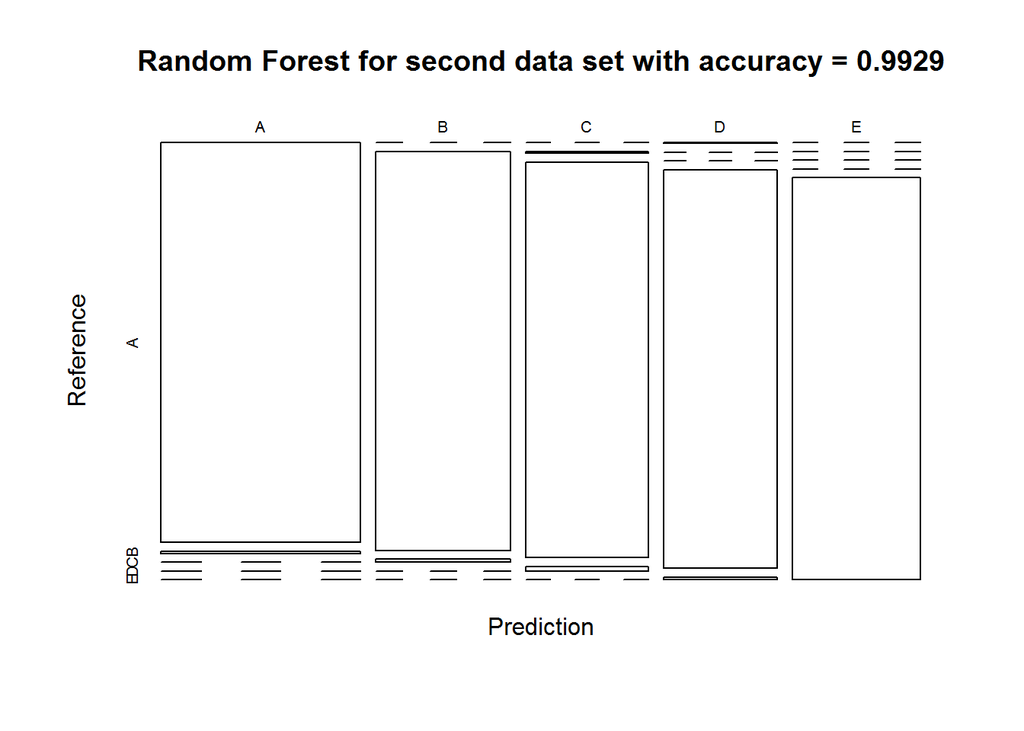

```r
plot(confMatRandForest1$table, col = confMatRandForest1$byClass, main = paste("Random Forest for second data set with accuracy =", round(confMatRandForest1$overall['Accuracy'], 4)))
```

For data set 2: Accurart = 0.9929 => out of sample error: 1- 0.9929 = 0.0071

Since each testing set has same size, then the overall out of sample error is avarage of these two number, or (0.0076 + 0.0071)/2 ~ 0.0074

Random Forest is the best among these. It is applied to predict 20 cases in the quiz:

```r
predictTEST <- predict(modFitRandForest, newdata=testing)
predictTEST
```

```
##  [1] B A A A A E D B A A B C B A E E A B B B
## Levels: A B C D E
```